# Quantifying My Daily Phone notifications

To understand how my digital environment impacts my daily life, I conducted an observational study building on Project 2. Using a custom Google Form, I recorded data every time my phone vibrated. I recorded the app category, word count, specific textual factors such as mentions, emojis, or question marks, what I was doing at the time, and my immediate reaction—whether I clicked immediately or ignored it. This visualization quantifies the nature of these daily distractions.

## Chapter 1: When Do I Typically Receive Notifications?

To understand the rhythm of my digital environment, we can observe the specific distribution of notifications received throughout the day. Converting the recorded timestamp strings into consecutive numerical hours accurately shows when my phone vibrates most frequently.

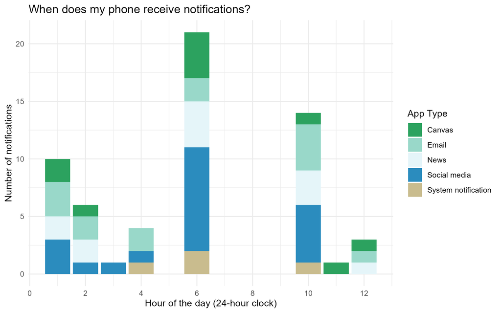

## Chapter 2: Different Text, Different Processing

Do certain surface textual features prompt me to react more quickly? Without reading the full message, I observed how specific visual cues—especially question marks, exclamation marks, and direct @ tags—influenced my immediate processing decisions.

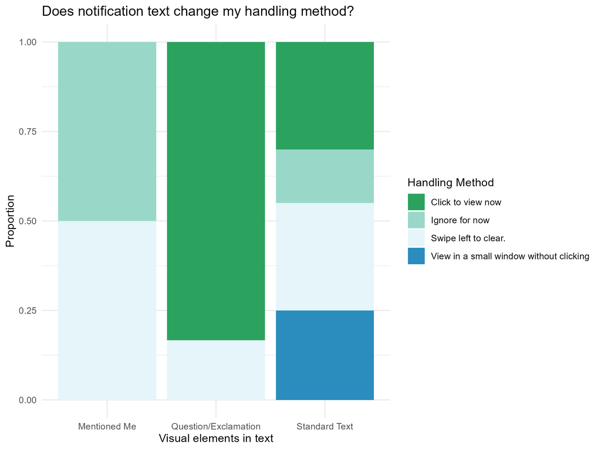

## Chapter 3: What I Was Doing When I Received Notifications

Finally, how does my real world intertwine with these notifications? By comparing the observed totals with what I was doing when I received notifications, we can identify where my attention is most vulnerable.

For readability, we plotted the variable levels, and a striking pattern emerges. I received the most notifications during breaks, workouts, and studying. This is likely because I spend a significant portion of my daily routine on these three things. This made me consider whether I should turn off my phone notifications during workouts and studying to help me focus better on what I’m doing.

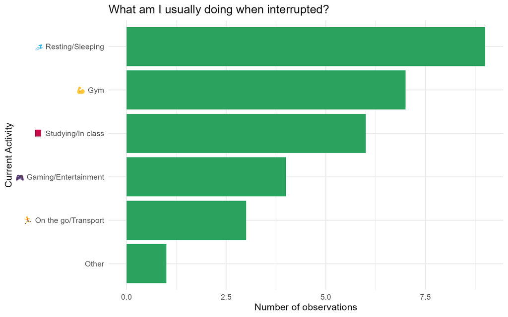

## Conclusion: Setting Data-Driven Boundaries

Through rigorous data processing and visual coding, this study successfully transformed raw observation logs into an objective audit of my digital space. By understanding hourly arrival rhythms, visual textual features that evoke reflections, and the most focused concrete real-world activities, such as resting or exercising at the gym, I can leverage these statistical insights to establish healthier, more proactive boundaries to resist external pressures.

[URL to the visual data story](https://samsong-16.github.io/Stats-220/visual_data_story.html)